# Geospatial Data Analytics with Python

## Introduction

This project will use Python to build a machine learning pipeline to predict the class label on how much Calgarians spend on automobile purchases. The study area will be Calgary, Alberta containing over 1700 dissemination areas. As mentioned, the target variable will be automobile purchase range. The predictor variables are:

- median age
- median household income
- average food spend
- average shelter spend
- marital status
- health care spend
- education (bachelor or above)

## Data Importing

The data used in this notebook is a sample of Dissemination Area data from the Business Analyst Canada 2023 dataset, provided by Esri Canada. It is for educational and demonstration purposes only, and should not be shared without permission.

The data comprises a small sample of Dissemination Areas roughly corresponding to the City of Calgary. The data was initially exported from ArcGIS Pro as a Shapefile. It has been enriched with several generic demographic and spending variables, intended to serve as predictors in our model building exercise.

As a spatial data set, we will use the GeoPandas package to import it into our notebook.

```python
import geopandas as gpd
import warnings
warnings.filterwarnings('ignore')

# Get the path to the Shapefile (this path will be different for you; please update it accordingly)
shapefile_path = r"C:\GDAA2000\Environment_Basics_Test\data\Calgary_DAs\Calgary_DAs.shp"

# Use GeoPandas to read/import the data
Cgy_DAs = gpd.read_file(shapefile_path)

# Examine the data to ensure it was imported correctly
Cgy_DAs.head()
```

|  | FID_Dissem | ID | NAME | ECYPTAPOP | RG_NAME | RG_ABBREV | FID_Calgar | HasData | aggregatio | Transporta | FiveYearPo | HouseholdI | Food_HSFD0 | Shelter_HS | MaritalSta | Educationa | HealthPers | Shape_Leng | Shape_Area | geometry |
| --- | --- | --- | --- | --- | --- | --- | --- | --- | --- | --- | --- | --- | --- | --- | --- | --- | --- | --- | --- | --- |
| 0 | 44587 | 48060492 | 48060492, AB | 908 | Alberta | AB | 1 | 1 | BlockApportionment:CAN.DA;PointsLayer:CAN.Bloc... | 641.39 | 47.6 | 115151.52 | 17615.02 | 23460.73 | 59.66 | 5.65 | 4949.24 | 3340.810022 | 572444.286522 | POLYGON ((-12699634.751 6606110.402, -12699634... |
| 1 | 44588 | 48060493 | 48060493, AB | 234 | Alberta | AB | 1 | 1 | BlockApportionment:CAN.DA;PointsLayer:CAN.Bloc... | 478.62 | 48.8 | 62222.22 | 10332.09 | 14280.22 | 61.22 | 8.84 | 4431.15 | 2193.157284 | 150220.404721 | POLYGON ((-12699122.905 6605438.965, -12699260... |
| 2 | 44589 | 48060494 | 48060494, AB | 645 | Alberta | AB | 1 | 1 | BlockApportionment:CAN.DA;PointsLayer:CAN.Bloc... | 592.58 | 38.9 | 107565.79 | 16377.94 | 22348.03 | 60.62 | 6.64 | 4805.64 | 3123.353545 | 404715.985743 | POLYGON ((-12698634.991 6605911.949, -12698635... |
| 3 | 44590 | 48060495 | 48060495, AB | 592 | Alberta | AB | 1 | 1 | BlockApportionment:CAN.DA;PointsLayer:CAN.Bloc... | 743.77 | 45.7 | 95172.41 | 13429.50 | 21703.53 | 54.08 | 12.01 | 4791.10 | 3158.510735 | 366501.639669 | POLYGON ((-12698634.991 6605911.949, -12698642... |
| 4 | 44591 | 48060496 | 48060496, AB | 664 | Alberta | AB | 1 | 1 | BlockApportionment:CAN.DA;PointsLayer:CAN.Bloc... | 560.25 | 40.7 | 112053.57 | 15587.77 | 20107.83 | 62.33 | 2.72 | 4719.79 | 2449.214703 | 353713.385114 | POLYGON ((-12699515.417 6606720.622, -12699478... |

## Data Cleaning and Exploration

Before we can advance to building a classification model, the data must be cleaned and explore. This is to ensure:

- selection of the appropriate features/columns releveant to for our purposes
- we understand the characteristics of the data
- the dataframe is free of missing values
- we are able to remove outliers, if there are any
- good model performace
- good model interpretabilty

### Selecting the Appropriate Variables

From the initial examination, we can see there are a number of extra variables that are unnecessary for our purposes. We will select the columns that are relevant to our project by first printing the column names to ensure our selections are spelled correctly.

```python
# Print column names
print(Cgy_DAs.columns)
```

```
Index(['FID_Dissem', 'ID', 'NAME', 'ECYPTAPOP', 'RG_NAME', 'RG_ABBREV',
       'FID_Calgar', 'HasData', 'aggregatio', 'Transporta', 'FiveYearPo',
       'HouseholdI', 'Food_HSFD0', 'Shelter_HS', 'MaritalSta', 'Educationa',
       'HealthPers', 'Shape_Leng', 'Shape_Area', 'geometry'],
      dtype='object')
```

```python
# Select columns
select = Cgy_DAs[['FID_Dissem', 'ID', 'ECYPTAPOP', 'Transporta', 'FiveYearPo', 'HouseholdI', 'Food_HSFD0',
                  'Shelter_HS', 'MaritalSta', 'Educationa', 'HealthPers', 'geometry']]

# Make new GeoDataFrame
Cgy_DAs = gpd.GeoDataFrame(select, geometry='geometry')

# Examine the new data
Cgy_DAs.head()
```

|  | FID_Dissem | ID | ECYPTAPOP | Transporta | FiveYearPo | HouseholdI | Food_HSFD0 | Shelter_HS | MaritalSta | Educationa | HealthPers | geometry |
| --- | --- | --- | --- | --- | --- | --- | --- | --- | --- | --- | --- | --- |
| 0 | 44587 | 48060492 | 908 | 641.39 | 47.6 | 115151.52 | 17615.02 | 23460.73 | 59.66 | 5.65 | 4949.24 | POLYGON ((-12699634.751 6606110.402, -12699634... |
| 1 | 44588 | 48060493 | 234 | 478.62 | 48.8 | 62222.22 | 10332.09 | 14280.22 | 61.22 | 8.84 | 4431.15 | POLYGON ((-12699122.905 6605438.965, -12699260... |
| 2 | 44589 | 48060494 | 645 | 592.58 | 38.9 | 107565.79 | 16377.94 | 22348.03 | 60.62 | 6.64 | 4805.64 | POLYGON ((-12698634.991 6605911.949, -12698635... |
| 3 | 44590 | 48060495 | 592 | 743.77 | 45.7 | 95172.41 | 13429.50 | 21703.53 | 54.08 | 12.01 | 4791.10 | POLYGON ((-12698634.991 6605911.949, -12698642... |
| 4 | 44591 | 48060496 | 664 | 560.25 | 40.7 | 112053.57 | 15587.77 | 20107.83 | 62.33 | 2.72 | 4719.79 | POLYGON ((-12699515.417 6606720.622, -12699478... |

### Fixing Variable Names

Now that we have selected our variables, we will rename them for easy interpratability. Ensure the changes were implemented correctly.

```python
# Fix variable names
Cgy_DAs = Cgy_DAs.rename(columns={
    'FID_Dissem': 'OBJECTID',
    'ECYPTAPOP': 'Population',
    'Transporta': 'Automobile_Avg',
    'FiveYearPo': 'Age_Median',
    'HouseholdI': 'Income_Median',
    'Food_HSFD0': 'Food_Avg',
    'Shelter_HS': 'Shelter_Avg',
    'MaritalSta': 'Marital_Ratio',
    'Educationa': 'Bachelor_and_Above',
    'HealthPers': 'Healthcare_Avg'
})

# Print the updated variable names to verify changes
print(Cgy_DAs.columns)
```

```
Index(['OBJECTID', 'ID', 'Population', 'Automobile_Avg', 'Age_Median',
       'Income_Median', 'Food_Avg', 'Shelter_Avg', 'Marital_Ratio',
       'Bachelor_and_Above', 'Healthcare_Avg', 'geometry'],
      dtype='object')
```

### Data Audit

Check that the data is parsed correctly, ensuring the data types of the variables are correct.

```python
# Verify the data types of each variable
print(Cgy_DAs.dtypes)
```

```
OBJECTID                 int64
ID                      object
Population               int64
Automobile_Avg         float64
Age_Median             float64
Income_Median          float64
Food_Avg               float64
Shelter_Avg            float64
Marital_Ratio          float64
Bachelor_and_Above     float64
Healthcare_Avg         float64
geometry              geometry
dtype: object
```

Data audits also involve ensuring there are no missing data.

```python
# Check for missing data
missing_data = Cgy_DAs.isnull().sum()

# Print the summary of missing data
print(missing_data[missing_data > 0])
```

```
Series([], dtype: int64)
```

Since checking the attribute table in ArcGIS, I noticed there were numerous rows with 0 values. These values seem like "fake" values. For this reason, I will be dropping the rows with the 0 values. Before I procede, I will check to make sure I have enough data points to justify dropping these rows and also check how many rows have 0 values.

```python
# Check total number of rows
num_rows = Cgy_DAs.shape[0]
print("Total number of rows:", num_rows)

zero_rows = (Cgy_DAs == 0).any(axis=1).sum()
print("Number of rows with 0 values:", zero_rows)
```

```
Total number of rows: 1707
Number of rows with 0 values: 148
```

Let's drop the 0 value rows.

```python
# Drop 0 value rows and check total number of rows after the drop.
Cgy_DAs = Cgy_DAs[(Cgy_DAs != 0).all(axis=1)]

num_rows = Cgy_DAs.shape[0]
print("Total number of rows:", num_rows)
```

```
Total number of rows: 1559
```

### Mapping the Target Variable

We can inspect the data using a simplified choropleth map to get a sense of the spacial distribution of our target and predictor variables, since we have a spatial data frame.

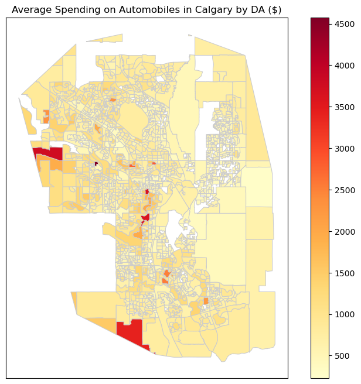

```python
from mapclassify import NaturalBreaks
import matplotlib.pyplot as plt

# Classify the data using natural breaks
classifier = NaturalBreaks(Cgy_DAs['Automobile_Avg'], k=5)

# Create the choropleth map
fig, ax = plt.subplots(1, 1, figsize=(10, 8))

Cgy_DAs.plot(column='Automobile_Avg', cmap='YlOrRd', linewidth=0.8, ax=ax, edgecolor='0.8',
                 legend=True, legend_kwds={'label': "", 'orientation': "vertical"})

# Remove axis labels and ticks
ax.set_xticks([])
ax.set_yticks([])
ax.set_xticklabels([])
ax.set_yticklabels([])

# Add title
plt.title('Average Spending on Automobiles in Calgary by DA ($)')

# Show the plot
plt.show()
```

This choropleth math does not look very good. There might be some outliers that is skewing our data. Let's explore the specnding distribution for `Automobile_Avg`.

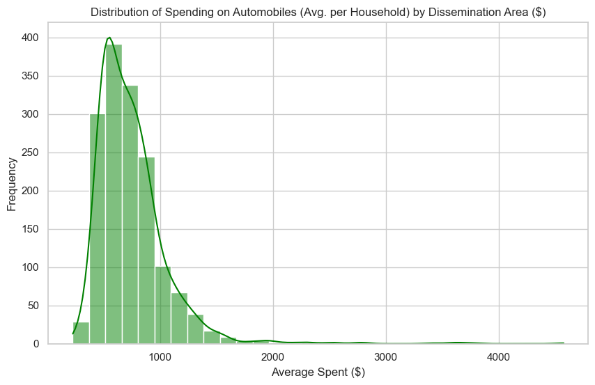

```python
import seaborn as sns
import matplotlib.pyplot as plt

# Use the 'style' argument to ensure that a grid appears (this is optional) in the plot
sns.set(style="whitegrid")

# Create a histogram using seaborn
plt.figure(figsize=(10, 6))
sns.histplot(data=Cgy_DAs, x='Automobile_Avg', bins=30, kde=True, color='green')
plt.title('Distribution of Spending on Automobiles (Avg. per Household) by Dissemination Area ($)')
plt.xlabel('Average Spent ($)')
plt.ylabel('Frequency')

plt.show()
```

It looks like there are a few outliers tat are greater than $2000 average spend that is skewing the data. As seen, there is a long right tail. Let's trim these outliers.

### Trimming the Outliers

There are many ways to determine if a value represents an outlier. One way is to use standard deviations, setting a specific threshold value beyond which values are considered outliers. For example, in this demonstration, we will use the threshold value of 3 standard deviations. That means, if a given DA has a `Automobile_Avg` value that is greater than or less than 3 standard deviations from the mean `Automobile_Avg` value, it will be considered an outlier and will be trimmed from the dataset.

A simple way to implement this approach is to convert the given numeric variable to a scaled version of itself using the z-score transformation, and then trimming any rows with values less than -3 or greater than 3. This works because z-score transformations rescale the numeric data so that they have means of zero and standard deviations in integer increments.

Here is the implementation of this approach, using 3 standard deviations as our threshold. Note: 3 is an arbitrary selection, and this parameter can be modified. Use your own judgement and domain knowledge to determine an appropriate value.

```python
from scipy import stats

# Calculate z-scores for the 'Food_Avg' variable
z_scores = stats.zscore(Cgy_DAs['Automobile_Avg'])

# Set the threshold for outliers (use a value that makes sense to you)
threshold = 3

# Trim the outliers
Cgy_DAs_trimmed = Cgy_DAs[(z_scores < threshold) & (z_scores > -threshold)]
```

Now that we have implemented the trimming operation, let us compare the input and output data frames to get a sense of how many samples were trimmed.

```python
# Verify the dimensions of the input and output data frames
print("Dimensions of Cgy_DAs:", Cgy_DAs.shape)
print("Dimensions of Cgy_DAs_trimmed:", Cgy_DAs_trimmed.shape)
```

```
Dimensions of Cgy_DAs: (1559, 12)
Dimensions of Cgy_DAs_trimmed: (1538, 12)
```

It looks like 21 instances were trimmed. Now, let's see if this makes a difference in the distribution of our target variable.

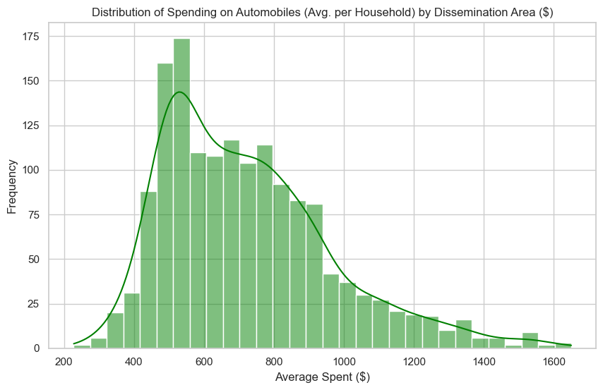

```python
sns.set(style="whitegrid")
plt.figure(figsize=(10, 6))
sns.histplot(data=Cgy_DAs_trimmed, x='Automobile_Avg', bins=30, kde=True, color='green')
plt.title('Distribution of Spending on Automobiles (Avg. per Household) by Dissemination Area ($)')
plt.xlabel('Average Spent ($)')
plt.ylabel('Frequency')
plt.show()
```

```python
x = (Cgy_DAs_trimmed['Automobile_Avg']).max()
num_rows_a = (Cgy_DAs_trimmed['Automobile_Avg'] > x).sum()
print("Number of rows where average auto spending is greater than {}: {}".format(x, num_rows_a))
```

```
Number of rows where average auto spending is greater than 1649.86: 0
```

Based on this histogram, it appears that our trimming operation was a success, though there is still a noticeable positive skew.

### Discretizing Target

Since we aiming to build a classification model, I need to discretize our target variable. Here, I adopt the `qcut` method and set the desired quantiles to 3, as I want my target variable to be binned into three categories: Low, Medium, and High.

```python
import pandas as pd

# Create labels for quantiles
labels = ["Low", "Medium", "High"]

# Discretize Food_Avg into four quantiles with equal counts and assign custom labels
Cgy_DAs_binned = Cgy_DAs_trimmed.copy()  # Make a copy to avoid modifying the original
Cgy_DAs_binned['Auto_Avg_Quantiles'] = pd.qcut(Cgy_DAs_trimmed['Automobile_Avg'], q=3, labels=labels)

# Preview the results
print(Cgy_DAs_binned[['Automobile_Avg', 'Auto_Avg_Quantiles']].head())
```

```
   Automobile_Avg Auto_Avg_Quantiles
0          641.39             Medium
1          478.62                Low
2          592.58             Medium
3          743.77             Medium
4          560.25                Low
```

From reviewing the output, I can see that the new variable was successfully added. In addition, it looks like the numeric values associated with the new variables are consistent with the class labels, so I am confident in proceeding.

To ensure that the new variable is balanced, I will create a quick bar plot.

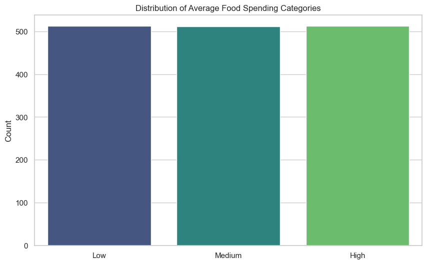

```python
sns.set(style="whitegrid")
plt.figure(figsize=(10, 6))
sns.countplot(data=Cgy_DAs_binned, x='Auto_Avg_Quantiles', order=labels, palette='viridis')
plt.title('Distribution of Average Food Spending Categories')
plt.xlabel('')
plt.ylabel('Count')
plt.show()
```

Good enough! You can see that it is not perfectly even accross all categories, but this is expected. Now, let's check that this variable's data type has changed.

```python
print(Cgy_DAs_binned.dtypes)
```

```
OBJECTID                 int64
ID                      object
Population               int64
Automobile_Avg         float64
Age_Median             float64
Income_Median          float64
Food_Avg               float64
Shelter_Avg            float64
Marital_Ratio          float64
Bachelor_and_Above     float64
Healthcare_Avg         float64
geometry              geometry
Auto_Avg_Quantiles    category
dtype: object
```

`Auto_Avg_Quantiles` is our new target variable, and it appears to be registered as a categorical variable, exactly as desired.

### Variable Selection

The next step in data preparation is to remove any unnecessary or redundant variables. In this case, I will remove the `OBJECTID`, `ID`, and `geometry` columns.

```python
# Selecting predictors and binned target variable from Hfx_DAs_binned
Cgy_DAs_select = Cgy_DAs_binned[['Population', 'Income_Median', 'Age_Median',
                                         'Food_Avg', 'Shelter_Avg', 'Marital_Ratio',
                                         'Bachelor_and_Above', 'Healthcare_Avg',
                                         'Auto_Avg_Quantiles']].copy()

print(Cgy_DAs_select.dtypes)
```

```
Population               int64
Income_Median          float64
Age_Median             float64
Food_Avg               float64
Shelter_Avg            float64
Marital_Ratio          float64
Bachelor_and_Above     float64
Healthcare_Avg         float64
Auto_Avg_Quantiles    category
dtype: object
```

### Re-Scaling the Data

The final step in preparation for modelling is to re-scale our data using z-score transformations. This ensures all of numeric predictors on the same scale, which prevents bias in the model building phase.

We will use the `StandardScaler` module from `scikit-learn` to scale our data.

```python
from sklearn.preprocessing import StandardScaler

# Set the scaler
scaler = StandardScaler()

# Select only the numeric variables
numeric_columns = ['Population', 'Income_Median', 'Age_Median',
                   'Food_Avg', 'Shelter_Avg', 'Marital_Ratio',
                   'Bachelor_and_Above', 'Healthcare_Avg']

# Transform the selected variables
Cgy_DAs_scaled = Cgy_DAs_select.copy()
Cgy_DAs_scaled[numeric_columns] = scaler.fit_transform(Cgy_DAs_scaled[numeric_columns])

print(Cgy_DAs_scaled.head())
```

```
   Population  Income_Median  Age_Median  Food_Avg  Shelter_Avg  \
0    0.022779       0.264029    1.013208  0.447639     0.086411
1   -0.651272      -1.112928    1.202986 -1.260666    -1.256376
2   -0.240241       0.066686   -0.362682  0.157466    -0.076338
3   -0.293245      -0.255728    0.712727 -0.534128    -0.170606
4   -0.221240       0.183436   -0.078015 -0.027878    -0.404001

   Marital_Ratio  Bachelor_and_Above  Healthcare_Avg Auto_Avg_Quantiles
0       0.422391           -0.834102       -0.252345             Medium
1       0.580473           -0.334873       -0.577589                Low
2       0.519672           -0.679169       -0.342493             Medium
3      -0.143056            0.161227       -0.351621             Medium
4       0.692954           -1.292642       -0.396388                Low
```

Everything looks to be re-scaled appropriately. We can now move on to modelling.

## Building a Classification Model

Using the `scikit-learn` package, I will build a simple classification model based on a decision tree.

## Create Training/Test Splits and Train the Model

The following code chunk uses the standard workflow for generating training/test splits of the data (to avoid overfitting), as well as training a simple classification model using the `DecisionTreeClassifier` from the `scikit-learn` package.

After loading the appropriate modules, I separate the predictors and target variable, split my data into training/test data (80/20), initialize the classifier, and train the model.

```python
from sklearn.tree import DecisionTreeClassifier
from sklearn.model_selection import train_test_split
from sklearn.metrics import accuracy_score, confusion_matrix, classification_report

# Separate predictors and target variable
X = Cgy_DAs_scaled[['Population', 'Income_Median', 'Age_Median',
                    'Food_Avg', 'Shelter_Avg', 'Marital_Ratio',
                    'Bachelor_and_Above', 'Healthcare_Avg']]
y = Cgy_DAs_scaled['Auto_Avg_Quantiles']

# Split the data into training and test sets
X_train, X_test, y_train, y_test = train_test_split(X, y, test_size=0.2)

# Initialize and train the model ------ clf is shorthand for classifier
clf = DecisionTreeClassifier(random_state=42).fit(X_train, y_train)
```

## Evaluate the Model

Now that the model is trained, we can evaluate it's performance. We will use Classification Accuracy and the Confusion Matrix as our primary scoring metrics.

```python
# Check the model accuracy
accuracy = accuracy_score(y_test, clf.predict(X_test))
print("Accuracy:", accuracy)
```

```
Accuracy: 0.6428571428571429
```

Our model accuracy appears to be okay. Not great, but not terrible either. More data would probably help in this case.

Now let's generate the confusion matrix and other metrics.

```python
# Calculate confusion matrix and classification report
conf_matrix = confusion_matrix(y_test, clf.predict(X_test))
class_report = classification_report(y_test, clf.predict(X_test))

# Print results
print("Confusion Matrix:\n", conf_matrix)
print("\nClassification Report:\n", class_report)
```

```
Confusion Matrix:
 [[83  2 21]
 [ 3 70 24]
 [22 38 45]]

Classification Report:
               precision    recall  f1-score   support

        High       0.77      0.78      0.78       106
         Low       0.64      0.72      0.68        97
      Medium       0.50      0.43      0.46       105

    accuracy                           0.64       308
   macro avg       0.63      0.64      0.64       308
weighted avg       0.64      0.64      0.64       308
```

This is not an effective way to visualize the confusion matrix. Let's turn it into a heatmap.

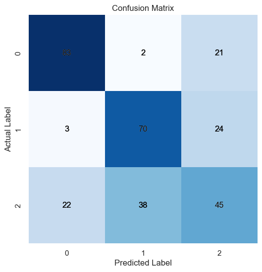

```python
# Plot confusion matrix as heatmap
plt.figure(figsize=(8, 6))
sns.heatmap(conf_matrix, annot=True, fmt='d', cmap='Blues', cbar=False, square=True)

# Add value annotations
for i in range(conf_matrix.shape[0]):
    for j in range(conf_matrix.shape[1]):
        plt.text(j + 0.5, i + 0.5, str(conf_matrix[i, j]), ha='center', va='center', color='black')

plt.title('Confusion Matrix')
plt.xlabel('Predicted Label')
plt.ylabel('Actual Label')
plt.show()
```

We can now visualize better what the results are. However, the class labels are not correct. This means creating a new plot woth appropriate labels.

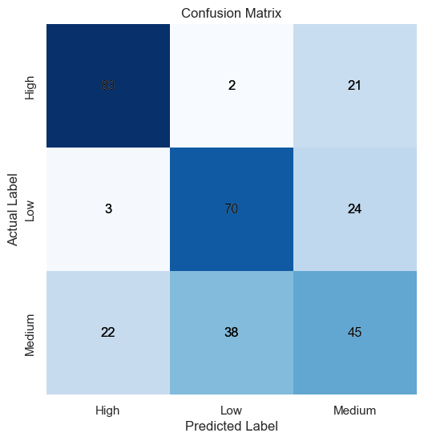

```python
import numpy as np

# Plot confusion matrix as heatmap
plt.figure(figsize=(8, 6))
sns.heatmap(conf_matrix, annot=True, fmt='d', cmap='Blues', cbar=False, square=True)

# Add value annotations
for i in range(conf_matrix.shape[0]):
    for j in range(conf_matrix.shape[1]):
        plt.text(j + 0.5, i + 0.5, str(conf_matrix[i, j]), ha='center', va='center', color='black')

# Fix tick labels
tick_labels = ['High', 'Low', 'Medium']
plt.xticks(ticks=np.arange(0.5, len(tick_labels)), labels=tick_labels)
plt.yticks(ticks=np.arange(0.5, len(tick_labels)), labels=tick_labels)

plt.title('Confusion Matrix')
plt.xlabel('Predicted Label')
plt.ylabel('Actual Label')
plt.show()
```

Note that here I have things ordered High, Low, and Medium. This is because the modelling process has encoded the target variables as numeric by first sorting the categorical data alphabetically.

## Summary

The model performance is not the best, by any means. However, it was able to predict correctly the majority of the data classification. As expected, the 'High' classification performed the best compared to the other two classes. This can likely be attributed to the positive skew of the dataset therefore, there would have been a more obvious distinction of classification from 'Medium' average spend to 'High' average spend. By the same logic, it makes sense that the model had a more challenging time correctly distunguishing between 'Low' and 'Medium' classes.

Ultimately, a better distribution of data and perhaps better predictor variable selections would result in a more accurate model.